# Distance vs. time. Acoustic and articulatory consequences of reduced vowel duration in Polish*

# 1 Overview

This supplementary document complements the paper *Distance vs. time. Articulatory and acoustic consequences of reduced vowel duration in Polish*.

The following sections illustrate:

1. The data extracted from ultrasound images, and the formants.
2. Descriptive plots of the raw data.
3. Code and plots of the linear regression models.
4. Summaries of the models in 3.
5. Extra analyses of F0.

Only relevant R code is shown in this document. The full code can be inspected on the OSF repository at https://osf.io/hy7nt/?view_only=d06775a2cb1d4786a0442b0f15d73296, in the file `code/analysis.Rmd`.

# 2 Atriculatory data processing

This is Figure 1 from the paper, which illustrates the articulatory data processing, as well as vowel formants. See paper for details.

```
## The origin is x = 16.8107470216526, y = -50.1837719761868.
```

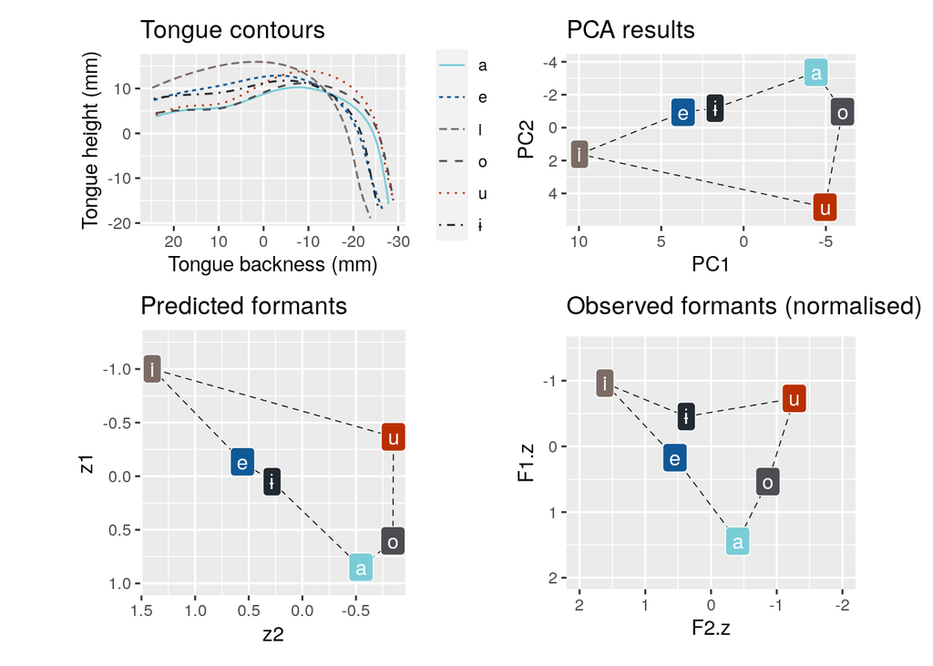

# 3 Descriptive statistics plots

## 3.1 Articulatory undershoot

Tongue contours from ultrasound tongue imaging of speaker PL01. Tongue tip on the right.

```
## The origin is x = 16.8107470216526, y = -50.1837719761868.
```

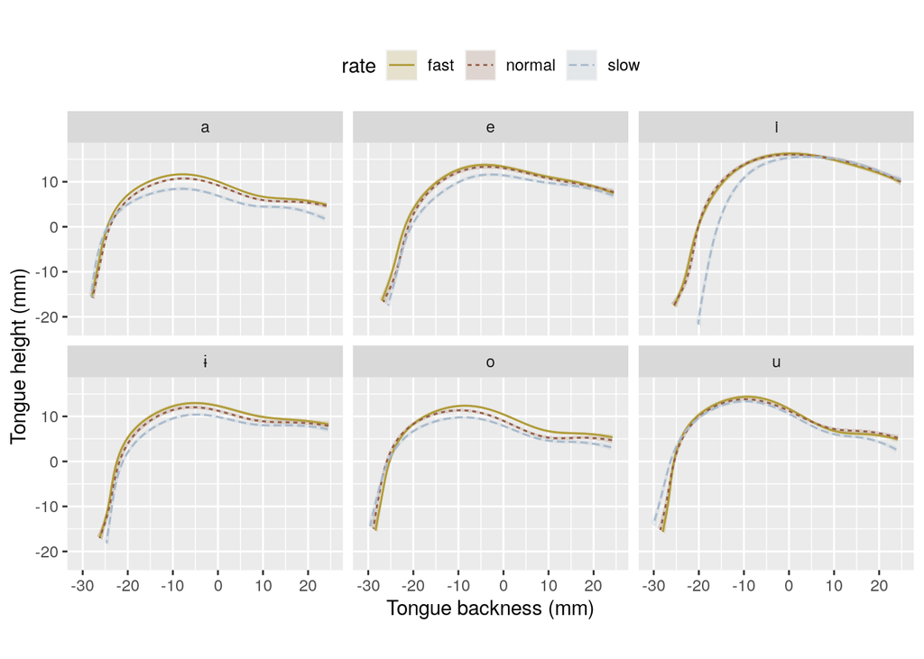

```
## The origin is x = 16.8107470216526, y = -50.1837719761868.
```

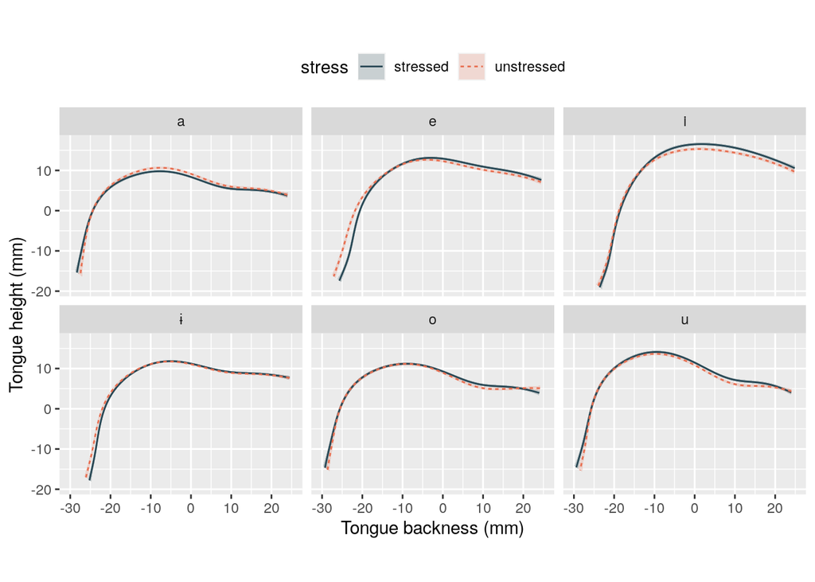

## 3.3 Vowel spaces

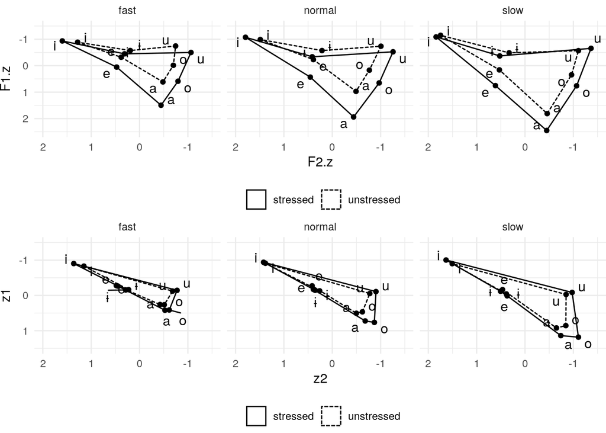

# 4 Inferential statistics

## 4.1 VIF (multicollinearity)

VIF values below 3 indicate absence of multicollinearity (Zuur, Ieno, and Elphick 2010). For all predictors, VIF < 3.

```
##   Variables      VIF
## 1  duration 2.169934
## 2      f1.z 1.379401
## 3      f2.z 1.208097
## 4      f0.z 1.122029
## 5      rate 1.639475
## 6    stress 1.451903
```

## 4.2 Duration

```
## NOTE: rate:stress is not a high-order term in the model
```

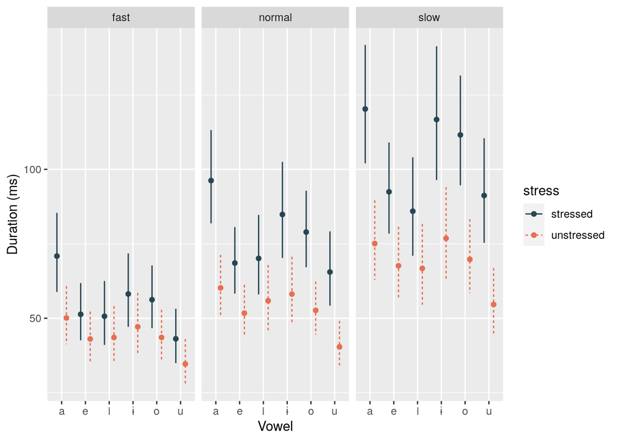

```
## refitting model(s) with ML (instead of REML)
```

```
## Data: midpoint_rotated
## Models:
## dur.lmer3: duration.log ~ (rate + stress | speaker) + (1 | frame) + rate *
## dur.lmer3:     V1 + stress
## dur.lmer2: duration.log ~ (rate + stress | speaker) + (1 | frame) + rate *
## dur.lmer2:     (V1 + stress)
## dur.lmer.full: duration.log ~ (rate + stress | speaker) + (1 | frame) + rate *
## dur.lmer.full:     V1 * stress
##               npar     AIC     BIC logLik deviance  Chisq Df Pr(>Chisq)
## dur.lmer3       31 -291.76 -128.32 176.88  -353.76
## dur.lmer2       33 -341.16 -167.17 203.58  -407.16 53.398  2  2.539e-12 ***
## dur.lmer.full   48 -375.61 -122.53 235.81  -471.61 64.450 15  4.265e-08 ***
## ---
## Signif. codes:  0 '***' 0.001 '**' 0.01 '*' 0.05 '.' 0.1 ' ' 1
```

## 4.3 F1

```
## refitting model(s) with ML (instead of REML)
```

```
## Data: midpoint_rotated
## Models:
## f1.lmer.base: f1.z ~ (1 | speaker) + (1 | frame) + V1 * duration
## f1.lmer.stress1: f1.z ~ (1 | speaker) + (1 | frame) + V1 * duration + stress
## f1.lmer.stress2: f1.z ~ (1 | speaker) + (1 | frame) + V1 * duration + V1 * stress
##                 npar    AIC    BIC  logLik deviance  Chisq Df Pr(>Chisq)
## f1.lmer.base      15 1760.5 1839.6 -865.24   1730.5
## f1.lmer.stress1   16 1697.3 1781.7 -832.68   1665.3 65.121  1  7.043e-16 ***
## f1.lmer.stress2   21 1671.0 1781.8 -814.51   1629.0 36.323  5  8.184e-07 ***
## ---
## Signif. codes:  0 '***' 0.001 '**' 0.01 '*' 0.05 '.' 0.1 ' ' 1
```

```
## # R2 for Mixed Models
##
##   Conditional R2: 0.830
##      Marginal R2: 0.772
```

```
## Random effect variances not available. Returned R2 does not account for random effects.
```

```
## # R2 for Mixed Models
##
##   Conditional R2: NA
##      Marginal R2: 0.828
```

```
## Random effect variances not available. Returned R2 does not account for random effects.
```

```
## # R2 for Mixed Models
##
##   Conditional R2: NA
##      Marginal R2: 0.832
```

```
## V1 = a:
##  contrast              estimate     SE   df t.ratio p.value
##  unstressed - stressed  -0.1947 0.0803 70.9 -2.426  0.0178
##
## V1 = e:
##  contrast              estimate     SE   df t.ratio p.value
##  unstressed - stressed  -0.3938 0.0721 46.9 -5.462  <.0001
##
## V1 = i:
##  contrast              estimate     SE   df t.ratio p.value
##  unstressed - stressed  -0.0232 0.0708 43.8 -0.328  0.7444
##
## V1 = o:
##  contrast              estimate     SE   df t.ratio p.value
##  unstressed - stressed  -0.4242 0.0750 54.8 -5.655  <.0001
##
## V1 = u:
##  contrast              estimate     SE   df t.ratio p.value
##  unstressed - stressed  -0.0926 0.0759 57.4 -1.219  0.2277
##
## V1 = ɨ:
##  contrast              estimate     SE   df t.ratio p.value
##  unstressed - stressed  -0.1340 0.0739 51.7 -1.813  0.0756
##
## Degrees-of-freedom method: kenward-roger
```

```
##  V1 duration.trend      SE   df t.ratio p.value
##  a        0.018822 0.00125 1388 15.103  <.0001
##  e        0.008974 0.00137 1411  6.568  <.0001
##  i       -0.003426 0.00132 1385 -2.596  0.0095
##  o        0.002798 0.00113 1408  2.468  0.0137
##  u        0.001214 0.00134 1399  0.905  0.3658
##  ɨ        0.000967 0.00109 1406  0.889  0.3742
##
## Results are averaged over the levels of: stress
## Degrees-of-freedom method: kenward-roger
```

## 4.4 F2

```
## refitting model(s) with ML (instead of REML)
```

```
## Data: midpoint_rotated
## Models:
## f2.lmer.base: f2.z ~ (1 | speaker) + (1 | frame) + V1 * duration
## f2.lmer.stress1: f2.z ~ (1 | speaker) + (1 | frame) + V1 * duration + stress
## f2.lmer.stress2: f2.z ~ (1 | speaker) + (1 | frame) + V1 * duration + V1 * stress
##                 npar    AIC    BIC  logLik deviance   Chisq Df Pr(>Chisq)
## f2.lmer.base      15 686.02 765.10 -328.01   656.02
## f2.lmer.stress1   16 685.78 770.14 -326.89   653.78  2.2395  1     0.1345
## f2.lmer.stress2   21 660.61 771.33 -309.31   618.61 35.1637  5  1.396e-06 ***
## ---
## Signif. codes:  0 '***' 0.001 '**' 0.01 '*' 0.05 '.' 0.1 ' ' 1
```

```
## Random effect variances not available. Returned R2 does not account for random effects.
```

```
## # R2 for Mixed Models
##
##   Conditional R2: NA
##      Marginal R2: 0.906
```

```
## Random effect variances not available. Returned R2 does not account for random effects.
```

```
## # R2 for Mixed Models
##
##   Conditional R2: NA
##      Marginal R2: 0.907
```

```
## Random effect variances not available. Returned R2 does not account for random effects.
```

```
## # R2 for Mixed Models
##
##   Conditional R2: NA
##      Marginal R2: 0.909
```

```
##  V1 duration.trend       SE    df t.ratio p.value
##  i         0.00640 0.000963 150.0  6.646  <.0001
##  ɨ         0.00357 0.000783  67.7  4.562  <.0001
##  u        -0.00620 0.000894 114.7 -6.927  <.0001
##  e         0.00361 0.000968 153.9  3.727  0.0003
##  a         0.00106 0.000790  71.7  1.345  0.1827
##  o        -0.00464 0.000792  72.3 -5.857  <.0001
##
## Degrees-of-freedom method: kenward-roger
```

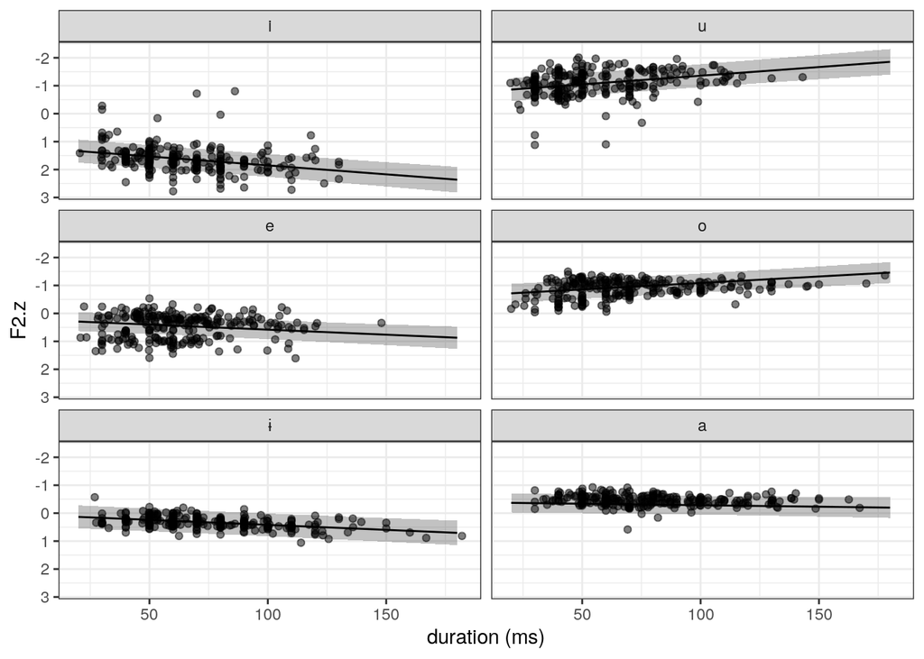

## 4.5 Z1

```
## refitting model(s) with ML (instead of REML)
```

```
## Data: midpoint_rotated
## Models:
## z1.lmer.base: z1 ~ (1 | speaker) + (1 | frame) + V1 * duration
## z1.lmer.stress1: z1 ~ (1 | speaker) + (1 | frame) + V1 * duration + stress
## z1.lmer.stress2: z1 ~ (1 | speaker) + (1 | frame) + V1 * duration + V1 * stress
##                 npar    AIC    BIC  logLik deviance  Chisq Df Pr(>Chisq)
## z1.lmer.base      15 1079.8 1158.9 -524.91   1049.8
## z1.lmer.stress1   16 1078.5 1162.9 -523.26   1046.5 3.3019  1     0.0692 .
## z1.lmer.stress2   21 1080.7 1191.4 -519.34   1038.7 7.8373  5     0.1654
## ---
## Signif. codes:  0 '***' 0.001 '**' 0.01 '*' 0.05 '.' 0.1 ' ' 1
```

```
## Random effect variances not available. Returned R2 does not account for random effects.
```

```
## # R2 for Mixed Models
##
##   Conditional R2: NA
##      Marginal R2: 0.731
```

```
## Random effect variances not available. Returned R2 does not account for random effects.
```

```
## # R2 for Mixed Models
##
##   Conditional R2: NA
##      Marginal R2: 0.732
```

```
## Random effect variances not available. Returned R2 does not account for random effects.
```

```
## # R2 for Mixed Models
##
##   Conditional R2: NA
##      Marginal R2: 0.732
```

```
##  V1 duration.trend      SE   df t.ratio p.value
##  i       -9.24e-04 0.00127 47.4 -0.726  0.4715
##  u        6.86e-05 0.00121 38.6  0.057  0.9549
##  e        4.13e-03 0.00128 48.3  3.234  0.0022
##  o        9.48e-03 0.00111 27.8  8.539  <.0001
##  ɨ       -4.45e-04 0.00110 26.8 -0.404  0.6892
##  a        8.89e-03 0.00111 27.5  8.028  <.0001
##
## Degrees-of-freedom method: kenward-roger
```

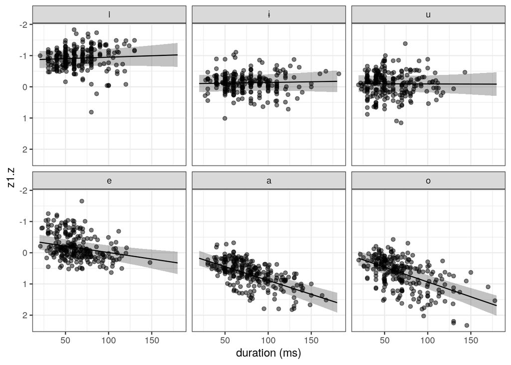

## 4.6 Z2

```
## refitting model(s) with ML (instead of REML)
```

```
## Data: midpoint_rotated
## Models:
## z2.lmer.base: z2 ~ (1 | speaker) + (1 | frame) + V1 * duration
## z2.lmer.stress1: z2 ~ (1 | speaker) + (1 | frame) + V1 * duration + stress
## z2.lmer.stress2: z2 ~ (1 | speaker) + (1 | frame) + V1 * duration + V1 * stress
##                 npar    AIC    BIC  logLik deviance  Chisq Df Pr(>Chisq)
## z2.lmer.base      15 753.97 833.06 -361.99   723.97
## z2.lmer.stress1   16 755.96 840.31 -361.98   723.96 0.0154  1     0.9011
## z2.lmer.stress2   21 760.46 871.18 -359.23   718.46 5.4935  5     0.3587
```

```
## # R2 for Mixed Models
##
##   Conditional R2: 0.896
##      Marginal R2: 0.721
```

```
## # R2 for Mixed Models
##
##   Conditional R2: 0.895
##      Marginal R2: 0.721
```

```
## # R2 for Mixed Models
##
##   Conditional R2: 0.896
##      Marginal R2: 0.721
```

```
##  V1 duration.trend       SE   df t.ratio p.value
##  i        0.004065 0.001140 43.4  3.565  0.0009
##  ɨ        0.003587 0.000992 25.0  3.617  0.0013
##  u       -0.003536 0.001083 35.4 -3.266  0.0024
##  e       -0.000651 0.001145 44.1 -0.568  0.5726
##  a       -0.003141 0.000997 25.6 -3.149  0.0041
##  o       -0.006695 0.000999 25.9 -6.700  <.0001
##
## Degrees-of-freedom method: kenward-roger
```

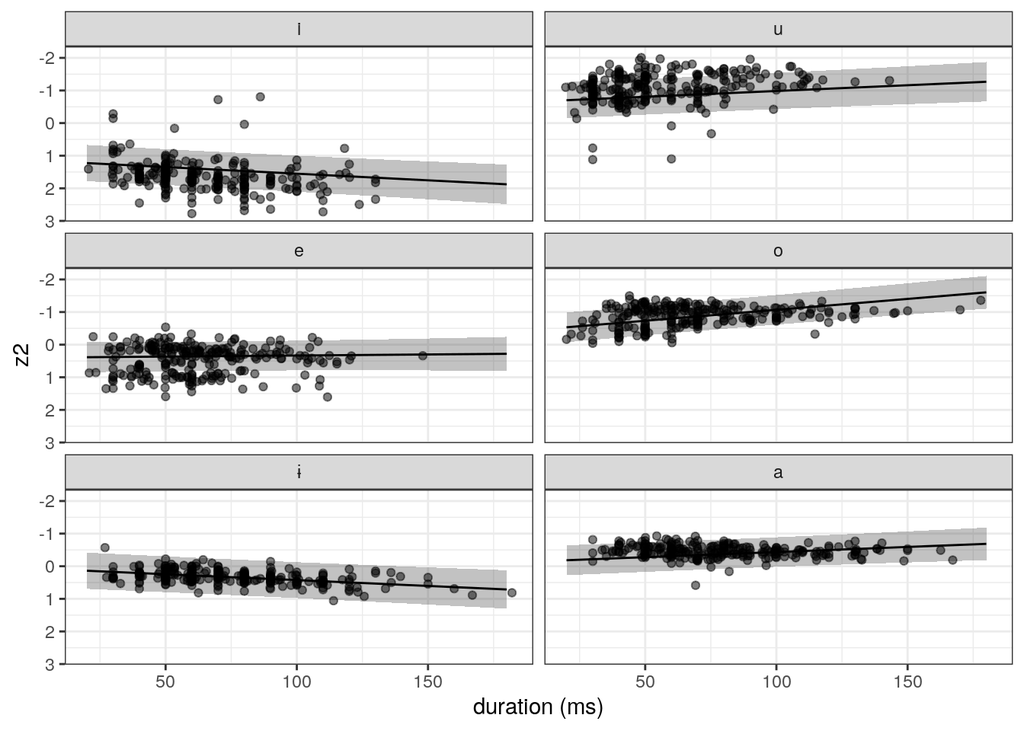

# 5 Model summaries

## 5.1 Duration

|  | duration.log |  |  |
| --- | --- | --- | --- |
| Predictors | Estimates | CI | p |
| (Intercept) | 3.9141 | 3.7210 – 4.1073 | **<0.001** |
| rate [normal] | 0.1837 | 0.0503 – 0.3171 | **0.00695** |
| rate [slow] | 0.4046 | 0.2410 – 0.5681 | **<0.001** |
| V1 [e] | -0.1518 | -0.3702 – 0.0666 | 0.17301 |
| V1 [i] | -0.1401 | -0.3792 – 0.0989 | 0.25052 |
| V1 [o] | -0.1400 | -0.2339 – -0.0461 | **0.00348** |
| V1 [u] | -0.3685 | -0.6075 – -0.1295 | **0.00251** |
| V1 [ɨ] | -0.0609 | -0.2999 – 0.1781 | 0.61743 |
| stress [stressed] | 0.3469 | 0.2532 – 0.4406 | **<0.001** |
| rate [normal] * V1 [e] | -0.0003 | -0.1236 – 0.1230 | 0.99631 |
| rate [slow] * V1 [e] | 0.0470 | -0.0763 – 0.1703 | 0.45488 |
| rate [normal] * V1 [i] | 0.0652 | -0.0581 – 0.1885 | 0.30010 |
| rate [slow] * V1 [i] | 0.0223 | -0.1010 – 0.1456 | 0.72308 |
| rate [normal] * V1 [o] | 0.0060 | -0.1174 – 0.1293 | 0.92441 |
| rate [slow] * V1 [o] | 0.0667 | -0.0566 – 0.1900 | 0.28922 |
| rate [normal] * V1 [u] | -0.0304 | -0.1537 – 0.0929 | 0.62884 |
| rate [slow] * V1 [u] | 0.0502 | -0.0732 – 0.1735 | 0.42539 |
| rate [normal] * V1 [ɨ] | 0.0257 | -0.0976 – 0.1491 | 0.68260 |
| rate [slow] * V1 [ɨ] | 0.0838 | -0.0395 – 0.2071 | 0.18283 |
| rate [normal] * stress [stressed] | 0.1222 | -0.0011 – 0.2455 | 0.05215 |
| rate [slow] * stress [stressed] | 0.1241 | 0.0008 – 0.2474 | **0.04860** |
| V1 [e] * stress [stressed] | -0.1709 | -0.2943 – -0.0476 | **0.00659** |
| V1 [i] * stress [stressed] | -0.1956 | -0.3189 – -0.0723 | **0.00188** |
| V1 [o] * stress [stressed] | -0.0915 | -0.2148 – 0.0319 | 0.14604 |
| V1 [u] * stress [stressed] | -0.1288 | -0.2521 – -0.0055 | **0.04067** |
| V1 [ɨ] * stress [stressed] | -0.1370 | -0.2603 – -0.0137 | **0.02947** |
| (rate [normal] * V1 [e]) * stress [stressed] | -0.0163 | -0.1907 – 0.1581 | 0.85479 |
| (rate [slow] * V1 [e]) * stress [stressed] | 0.0129 | -0.1615 – 0.1873 | 0.88476 |
| (rate [normal] * V1 [i]) * stress [stressed] | -0.0466 | -0.2210 – 0.1279 | 0.60089 |
| (rate [slow] * V1 [i]) * stress [stressed] | -0.0225 | -0.1969 – 0.1519 | 0.80071 |
| (rate [normal] * V1 [o]) * stress [stressed] | 0.0273 | -0.1471 – 0.2018 | 0.75863 |
| (rate [slow] * V1 [o]) * stress [stressed] | 0.0897 | -0.0847 – 0.2641 | 0.31329 |
| (rate [normal] * V1 [u]) * stress [stressed] | 0.1434 | -0.0310 – 0.3178 | 0.10708 |
| (rate [slow] * V1 [u]) * stress [stressed] | 0.1707 | -0.0037 – 0.3451 | 0.05511 |
| (rate [normal] * V1 [ɨ]) * stress [stressed] | 0.0462 | -0.1282 – 0.2206 | 0.60374 |
| (rate [slow] * V1 [ɨ]) * stress [stressed] | 0.0843 | -0.0901 – 0.2587 | 0.34349 |
| Random Effects |  |  |  |
| σ<sup>2</sup> | 0.0396 |  |  |
| τ<sub>00</sub> <sub>frame</sub> | 0.0154 |  |  |
| τ<sub>00</sub> <sub>speaker</sub> | 0.0351 |  |  |
| τ<sub>11</sub> <sub>speaker.ratenormal</sub> | 0.0265 |  |  |
| τ<sub>11</sub> <sub>speaker.rateslow</sub> | 0.0498 |  |  |
| τ<sub>11</sub> <sub>speaker.stressstressed</sub> | 0.0031 |  |  |
| ρ<sub>01</sub> <sub>speaker.ratenormal</sub> | -0.8117 |  |  |
| ρ<sub>01</sub> <sub>speaker.rateslow</sub> | -0.7847 |  |  |
| ρ<sub>01</sub> <sub>speaker.stressstressed</sub> | -0.4845 |  |  |
| N <sub>speaker</sub> | 10 |  |  |
| N <sub>frame</sub> | 12 |  |  |
| Observations | 1440 |  |  |
| Marginal R<sup>2</sup> / Conditional R<sup>2</sup> | 0.706 / NA |  |  |

## 5.2 F1

|  | f1.z |  |  |
| --- | --- | --- | --- |
| Predictors | Estimates | CI | p |
| (Intercept) | 0.1655 | -0.1791 – 0.5100 | 0.34663 |
| V1 [e] | -0.8117 | -1.2978 – -0.3256 | **0.00106** |
| V1 [i] | -0.9752 | -1.5034 – -0.4470 | **0.00030** |
| V1 [o] | -0.3559 | -0.5734 – -0.1385 | **0.00133** |
| V1 [u] | -0.9014 | -1.4215 – -0.3814 | **0.00068** |
| V1 [ɨ] | -0.7690 | -1.2931 – -0.2448 | **0.00403** |
| duration | 0.0188 | 0.0164 – 0.0212 | **<0.001** |
| stress [stressed] | 0.1947 | 0.0376 – 0.3517 | **0.01510** |
| V1 [e] * duration | -0.0098 | -0.0135 – -0.0062 | **<0.001** |
| V1 [i] * duration | -0.0222 | -0.0258 – -0.0187 | **<0.001** |
| V1 [o] * duration | -0.0160 | -0.0193 – -0.0127 | **<0.001** |
| V1 [u] * duration | -0.0176 | -0.0212 – -0.0140 | **<0.001** |
| V1 [ɨ] * duration | -0.0179 | -0.0211 – -0.0146 | **<0.001** |
| V1 [e] * stress [stressed] | 0.1991 | 0.0232 – 0.3750 | **0.02656** |
| V1 [i] * stress [stressed] | -0.1714 | -0.3454 – 0.0025 | 0.05344 |
| V1 [o] * stress [stressed] | 0.2295 | 0.0490 – 0.4101 | **0.01269** |
| V1 [u] * stress [stressed] | -0.1021 | -0.2841 – 0.0799 | 0.27162 |
| V1 [ɨ] * stress [stressed] | -0.0607 | -0.2395 – 0.1181 | 0.50568 |
| Random Effects |  |  |  |
| σ<sup>2</sup> | 0.1740 |  |  |
| τ<sub>00</sub> <sub>frame</sub> | 0.0697 |  |  |
| τ<sub>00</sub> <sub>speaker</sub> | 0.0029 |  |  |
| τ<sub>11</sub> <sub>speaker.stressstressed</sub> | 0.0178 |  |  |
| ρ<sub>01</sub> <sub>speaker</sub> | -1.0000 |  |  |
| N <sub>speaker</sub> | 10 |  |  |
| N <sub>frame</sub> | 12 |  |  |
| Observations | 1440 |  |  |
| Marginal R<sup>2</sup> / Conditional R<sup>2</sup> | 0.836 / NA |  |  |

## 5.3 F2

|  | f2.z |  |  |
| --- | --- | --- | --- |
| Predictors | Estimates | CI | p |
| (Intercept) | 1.2118 | 0.7901 – 1.6334 | **<0.001** |
| V1 [ɨ] | -1.1489 | -1.7404 – -0.5573 | **0.00014** |
| V1 [u] | -1.9509 | -2.5405 – -1.3613 | **<0.001** |
| V1 [e] | -0.9911 | -1.5380 – -0.4441 | **0.00038** |
| V1 [a] | -1.6015 | -2.1469 – -1.0561 | **<0.001** |
| V1 [o] | -1.8373 | -2.3803 – -1.2943 | **<0.001** |
| duration | 0.0064 | 0.0045 – 0.0083 | **<0.001** |
| V1 [ɨ] * duration | -0.0028 | -0.0050 – -0.0006 | **0.01181** |
| V1 [u] * duration | -0.0126 | -0.0150 – -0.0102 | **<0.001** |
| V1 [e] * duration | -0.0028 | -0.0053 – -0.0003 | **0.02699** |
| V1 [a] * duration | -0.0053 | -0.0076 – -0.0031 | **<0.001** |
| V1 [o] * duration | -0.0110 | -0.0133 – -0.0088 | **<0.001** |
| Random Effects |  |  |  |
| σ<sup>2</sup> | 0.0889 |  |  |
| τ<sub>00</sub> <sub>frame</sub> | 0.0844 |  |  |
| τ<sub>00</sub> <sub>speaker</sub> | 0.0043 |  |  |
| τ<sub>11</sub> <sub>speaker.duration</sub> | 0.0000 |  |  |
| ρ<sub>01</sub> <sub>speaker</sub> | -1.0000 |  |  |
| N <sub>speaker</sub> | 10 |  |  |
| N <sub>frame</sub> | 12 |  |  |
| Observations | 1440 |  |  |
| Marginal R<sup>2</sup> / Conditional R<sup>2</sup> | 0.907 / NA |  |  |

## 5.4 Z1

|  | z1 |  |  |
| --- | --- | --- | --- |
| Predictors | Estimates | CI | p |
| (Intercept) | -0.8560 | -1.1544 – -0.5576 | **<0.001** |
| V1 [u] | 0.7575 | 0.3657 – 1.1493 | **0.00015** |
| V1 [e] | 0.4365 | 0.0621 – 0.8108 | **0.02230** |
| V1 [o] | 0.8455 | 0.4785 – 1.2125 | **0.00001** |
| V1 [ɨ] | 0.7612 | 0.3656 – 1.1568 | **0.00016** |
| V1 [a] | 0.8547 | 0.4831 – 1.2263 | **0.00001** |
| duration | -0.0009 | -0.0034 – 0.0016 | 0.46612 |
| V1 [u] * duration | 0.0010 | -0.0017 – 0.0037 | 0.46909 |
| V1 [e] * duration | 0.0051 | 0.0022 – 0.0079 | **0.00044** |
| V1 [o] * duration | 0.0104 | 0.0079 – 0.0129 | **<0.001** |
| V1 [ɨ] * duration | 0.0005 | -0.0020 – 0.0030 | 0.70838 |
| V1 [a] * duration | 0.0098 | 0.0073 – 0.0123 | **<0.001** |
| Random Effects |  |  |  |
| σ<sup>2</sup> | 0.1154 |  |  |
| τ<sub>00</sub> <sub>frame</sub> | 0.0320 |  |  |
| τ<sub>00</sub> <sub>speaker</sub> | 0.0239 |  |  |
| τ<sub>11</sub> <sub>speaker.duration</sub> | 0.0000 |  |  |
| ρ<sub>01</sub> <sub>speaker</sub> | -0.9948 |  |  |
| ICC | 0.2402 |  |  |
| N <sub>speaker</sub> | 10 |  |  |
| N <sub>frame</sub> | 12 |  |  |
| Observations | 1440 |  |  |
| Marginal R<sup>2</sup> / Conditional R<sup>2</sup> | 0.680 / 0.757 |  |  |

## 5.5 Z2

|  | z2 |  |  |
| --- | --- | --- | --- |
| Predictors | Estimates | CI | p |
| (Intercept) | 1.1460 | 0.5813 – 1.7108 | **0.00007** |
| V1 [ɨ] | -1.0785 | -1.8663 – -0.2906 | **0.00730** |
| V1 [u] | -1.7767 | -2.5631 – -0.9903 | **0.00001** |
| V1 [e] | -0.7474 | -1.4719 – -0.0228 | **0.04321** |
| V1 [a] | -1.2666 | -1.9899 – -0.5433 | **0.00060** |
| V1 [o] | -1.5449 | -2.2664 – -0.8234 | **0.00003** |
| duration | 0.0041 | 0.0018 – 0.0063 | **0.00035** |
| V1 [ɨ] * duration | -0.0005 | -0.0027 – 0.0017 | 0.67125 |
| V1 [u] * duration | -0.0076 | -0.0100 – -0.0052 | **<0.001** |
| V1 [e] * duration | -0.0047 | -0.0072 – -0.0022 | **0.00020** |
| V1 [a] * duration | -0.0072 | -0.0094 – -0.0050 | **<0.001** |
| V1 [o] * duration | -0.0108 | -0.0130 – -0.0085 | **<0.001** |
| Random Effects |  |  |  |
| σ<sup>2</sup> | 0.0889 |  |  |
| τ<sub>00</sub> <sub>frame</sub> | 0.1548 |  |  |
| τ<sub>00</sub> <sub>speaker</sub> | 0.0190 |  |  |
| τ<sub>11</sub> <sub>speaker.duration</sub> | 0.0000 |  |  |
| ρ<sub>01</sub> <sub>speaker</sub> | -0.9900 |  |  |
| ICC | 0.6412 |  |  |
| N <sub>speaker</sub> | 10 |  |  |
| N <sub>frame</sub> | 12 |  |  |
| Observations | 1440 |  |  |
| Marginal R<sup>2</sup> / Conditional R<sup>2</sup> | 0.722 / 0.900 |  |  |

# 6 Further exploratory analyses

## 6.1 F0

```
## refitting model(s) with ML (instead of REML)
```

```
## Data: midpoint_rotated
## Models:
## f0.lmer1: f0.z ~ (1 | speaker) + (1 | frame) + V1 + duration + stress
## f0.lmer2: f0.z ~ (1 | speaker) + (1 | frame) + V1 * duration + stress
## f0.lmer3: f0.z ~ (1 | speaker) + (1 | frame) + V1 * duration + V1 * stress
##          npar    AIC    BIC  logLik deviance   Chisq Df Pr(>Chisq)
## f0.lmer1   11 3832.2 3890.2 -1905.1   3810.2
## f0.lmer2   16 3816.6 3900.9 -1892.3   3784.6 25.6465  5  0.0001045 ***
## f0.lmer3   21 3825.9 3936.6 -1892.0   3783.9  0.6865  5  0.9837038
## ---
## Signif. codes:  0 '***' 0.001 '**' 0.01 '*' 0.05 '.' 0.1 ' ' 1
```

|  | f0.z |  |  |
| --- | --- | --- | --- |
| Predictors | Estimates | CI | p |
| (Intercept) | -0.65 | -0.82 – -0.49 | **<0.001** |
| V11 | -0.26 | -0.64 – 0.11 | 0.171 |
| V12 | 0.39 | 0.05 – 0.74 | **0.026** |
| V13 | 0.09 | -0.28 – 0.46 | 0.629 |
| V14 | 0.04 | -0.28 – 0.36 | 0.820 |
| V15 | -0.37 | -0.73 – -0.00 | **0.047** |
| duration | 0.01 | 0.01 – 0.01 | **<0.001** |
| stress [stressed] | 0.29 | 0.19 – 0.40 | **<0.001** |
| V11 * duration | 0.00 | -0.00 – 0.01 | 0.053 |
| V12 * duration | 0.01 | 0.00 – 0.01 | **0.018** |
| V13 * duration | -0.00 | -0.01 – 0.00 | 0.055 |
| V14 * duration | -0.00 | -0.01 – 0.00 | 0.187 |
| V15 * duration | 0.00 | 0.00 – 0.01 | **0.042** |
| Random Effects |  |  |  |
| σ<sup>2</sup> | 0.81 |  |  |
| τ<sub>00</sub> <sub>frame</sub> | 0.03 |  |  |
| τ<sub>00</sub> <sub>speaker</sub> | 0.00 |  |  |
| N <sub>speaker</sub> | 10 |  |  |
| N <sub>frame</sub> | 12 |  |  |
| Observations | 1436 |  |  |
| Marginal R<sup>2</sup> / Conditional R<sup>2</sup> | 0.186 / NA |  |  |

Zuur, Alain F., Elena N. Ieno, and Chris S. Elphick. 2010. “A Protocol for Data Exploration to Avoid Common Statistical Problems.” *Methods in Ecology and Evolution* 1 (1): 3–14. https://doi.org/10.1111/j.2041-210X.2009.00001.x.